# Practical Machine Learning. Course Project

Alexander Popov

22 Aug 2015

### Overview

In this project, our goal is to predict the manner in which 6 participants did the barbell lifting exercise: correctly or incorrectly in 5 different ways. The relevant data was collected from accelerometers on the belt, forearm, arm, and dumbell. All the data comes from this source: http://groupware.les.inf.puc-rio.br/har (section on the Weight Lifting Exercise)

### Training and test data

The training and test data for this project were taken from here:

https://d396qusza40orc.cloudfront.net/predmachlearn/pml-training.csv

https://d396qusza40orc.cloudfront.net/predmachlearn/pml-testing.csv

They were then downloaded onto the local machine so that they could be easier used in the course project:

```r
setwd("~/Practical Machine Learning/COURSE PROJECT")
training.data=read.csv("~/Practical Machine Learning/COURSE PROJECT/pml-training.csv")
dim(training.data)
```

```
## [1] 19622   160
```

```r
testing.data=read.csv("~/Practical Machine Learning/COURSE PROJECT/pml-testing.csv")
dim(testing.data)
```

```
## [1]  20 160
```

The response variable is “classe”:

```r
summary(training.data$classe)
```

```
##    A    B    C    D    E
## 5580 3797 3422 3216 3607
```

Response variable is not continuous - it has 5 levels. Therefore we conclude that this is a typical classification problem.

Looking at the data we see that there are 159 possible predictors. The first thing we want to do about them is to remove those which are all NA’s on the test data:

```r
ind=NULL
for (i in 1:length(testing.data)) {
        len=length(levels(factor(testing.data[,i])))
        if (len<1) ind=c(ind,i)
}
training.data=training.data[,-ind]
names(training.data)
```

```
##  [1] "X"                    "user_name"            "raw_timestamp_part_1"
##  [4] "raw_timestamp_part_2" "cvtd_timestamp"       "new_window"
##  [7] "num_window"           "roll_belt"            "pitch_belt"
## [10] "yaw_belt"             "total_accel_belt"     "gyros_belt_x"
## [13] "gyros_belt_y"         "gyros_belt_z"         "accel_belt_x"
## [16] "accel_belt_y"         "accel_belt_z"         "magnet_belt_x"
## [19] "magnet_belt_y"        "magnet_belt_z"        "roll_arm"
## [22] "pitch_arm"            "yaw_arm"              "total_accel_arm"
## [25] "gyros_arm_x"          "gyros_arm_y"          "gyros_arm_z"
## [28] "accel_arm_x"          "accel_arm_y"          "accel_arm_z"
## [31] "magnet_arm_x"         "magnet_arm_y"         "magnet_arm_z"
## [34] "roll_dumbbell"        "pitch_dumbbell"       "yaw_dumbbell"
## [37] "total_accel_dumbbell" "gyros_dumbbell_x"     "gyros_dumbbell_y"
## [40] "gyros_dumbbell_z"     "accel_dumbbell_x"     "accel_dumbbell_y"
## [43] "accel_dumbbell_z"     "magnet_dumbbell_x"    "magnet_dumbbell_y"
## [46] "magnet_dumbbell_z"    "roll_forearm"         "pitch_forearm"
## [49] "yaw_forearm"          "total_accel_forearm"  "gyros_forearm_x"
## [52] "gyros_forearm_y"      "gyros_forearm_z"      "accel_forearm_x"
## [55] "accel_forearm_y"      "accel_forearm_z"      "magnet_forearm_x"
## [58] "magnet_forearm_y"     "magnet_forearm_z"     "classe"
```

```r
testing.data=testing.data[,-ind]
names(testing.data)
```

```
##  [1] "X"                    "user_name"            "raw_timestamp_part_1"
##  [4] "raw_timestamp_part_2" "cvtd_timestamp"       "new_window"
##  [7] "num_window"           "roll_belt"            "pitch_belt"
## [10] "yaw_belt"             "total_accel_belt"     "gyros_belt_x"
## [13] "gyros_belt_y"         "gyros_belt_z"         "accel_belt_x"
## [16] "accel_belt_y"         "accel_belt_z"         "magnet_belt_x"
## [19] "magnet_belt_y"        "magnet_belt_z"        "roll_arm"
## [22] "pitch_arm"            "yaw_arm"              "total_accel_arm"
## [25] "gyros_arm_x"          "gyros_arm_y"          "gyros_arm_z"
## [28] "accel_arm_x"          "accel_arm_y"          "accel_arm_z"
## [31] "magnet_arm_x"         "magnet_arm_y"         "magnet_arm_z"
## [34] "roll_dumbbell"        "pitch_dumbbell"       "yaw_dumbbell"
## [37] "total_accel_dumbbell" "gyros_dumbbell_x"     "gyros_dumbbell_y"
## [40] "gyros_dumbbell_z"     "accel_dumbbell_x"     "accel_dumbbell_y"
## [43] "accel_dumbbell_z"     "magnet_dumbbell_x"    "magnet_dumbbell_y"
## [46] "magnet_dumbbell_z"    "roll_forearm"         "pitch_forearm"
## [49] "yaw_forearm"          "total_accel_forearm"  "gyros_forearm_x"
## [52] "gyros_forearm_y"      "gyros_forearm_z"      "accel_forearm_x"
## [55] "accel_forearm_y"      "accel_forearm_z"      "magnet_forearm_x"
## [58] "magnet_forearm_y"     "magnet_forearm_z"     "problem_id"
```

We can notice the reduction by 100 variables which is very good, it will be much easier to asses the remaining variables.

Let’s go on with dimensionality reduction. We will remove “X” because it’s just an observation id. We will remove “raw_timestamp_part_1”, “raw_timestamp_part_2” and “cvtd_timestamp” because they are time stamps and we don’t think they can impact the response variable at all.

We will go on with removing low-impact variables from the model. We will determine the impact of each predictor variable on the response variable “classe” by doing boxplot analysis. We will show 3 examples of such analysis.

##### Example 1.

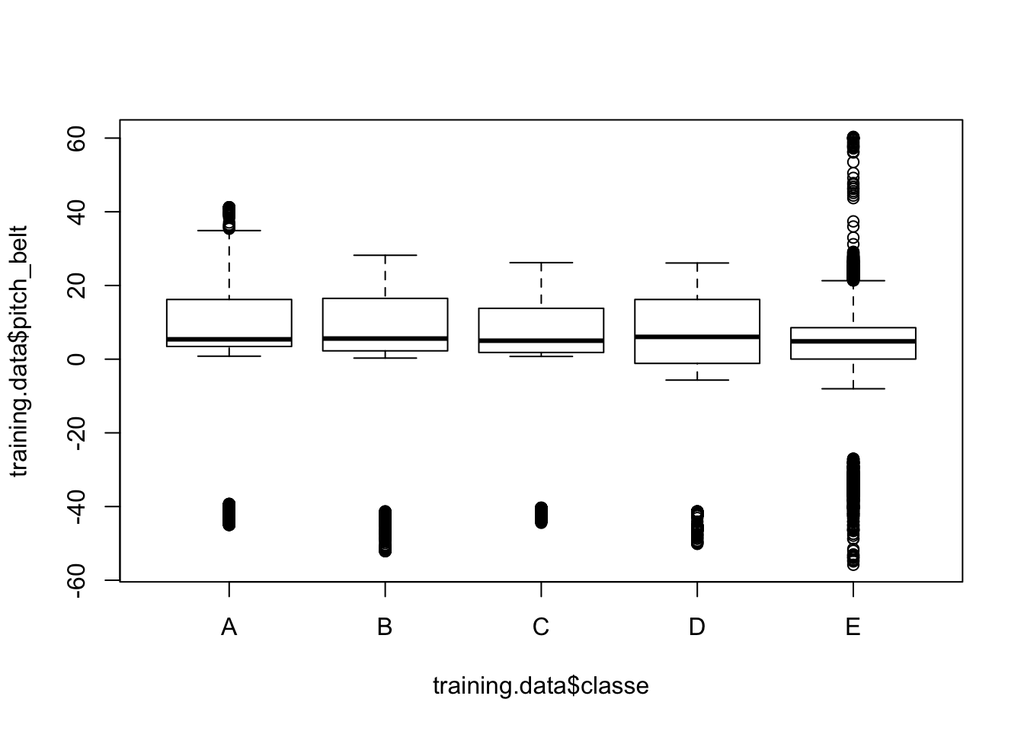

```r
plot(training.data$pitch_belt~training.data$classe)
```

##### Example 2.

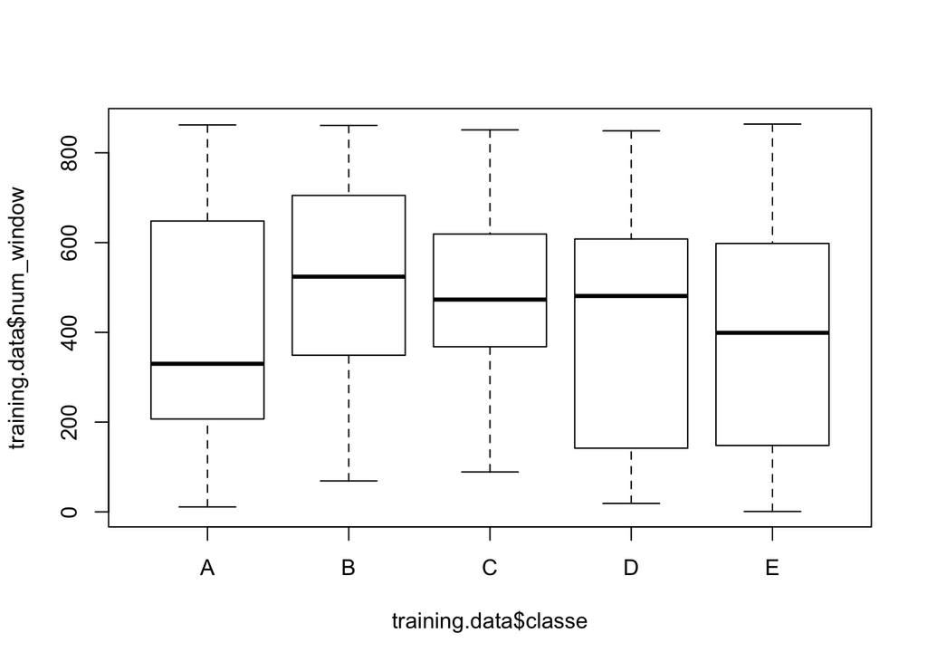

```r
plot(training.data$num_window~training.data$classe)
```

##### Example 3.

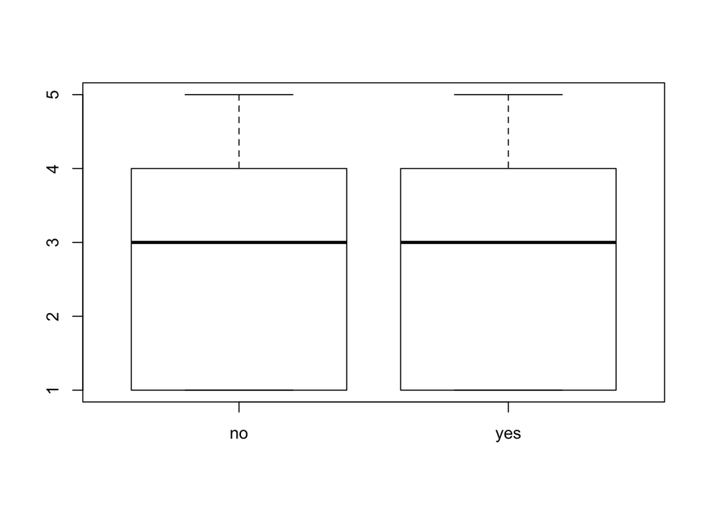

```r
int_classe=training.data$classe
library(plyr)
int_classe=mapvalues(int_classe,levels(as.factor(training.data$classe)),1:length(levels(as.factor(training.data$classe))))
int_classe=as.numeric(int_classe)
boxplot(int_classe~training.data$new_window)
```

We can see that variable “new_window” does not have an impact on response variable (we transfromed here response variable from factor to numeric): the medians, lower and upper quartiles in each class of predictor are the same. Variable “new_window” should be removed from the model.

As a result of such analysis, we make a decision to include 19 following predictors in the model:

```r
include_ind=c("user_name","num_window","roll_belt","yaw_belt","magnet_belt_y","magnet_belt_z","accel_arm_x","magnet_arm_x","magnet_arm_y","roll_dumbbell","pitch_dumbbell","accel_dumbbell_x","magnet_dumbbell_x","magnet_dumbbell_y","magnet_dumbbell_z","roll_forearm","accel_forearm_x","magnet_forearm_x","magnet_forearm_y")
training.data=training.data[,c(include_ind,"classe")]
names(training.data)
```

```
##  [1] "user_name"         "num_window"        "roll_belt"
##  [4] "yaw_belt"          "magnet_belt_y"     "magnet_belt_z"
##  [7] "accel_arm_x"       "magnet_arm_x"      "magnet_arm_y"
## [10] "roll_dumbbell"     "pitch_dumbbell"    "accel_dumbbell_x"
## [13] "magnet_dumbbell_x" "magnet_dumbbell_y" "magnet_dumbbell_z"
## [16] "roll_forearm"      "accel_forearm_x"   "magnet_forearm_x"
## [19] "magnet_forearm_y"  "classe"
```

```r
testing.data=testing.data[,include_ind]
names(testing.data)
```

```
##  [1] "user_name"         "num_window"        "roll_belt"
##  [4] "yaw_belt"          "magnet_belt_y"     "magnet_belt_z"
##  [7] "accel_arm_x"       "magnet_arm_x"      "magnet_arm_y"
## [10] "roll_dumbbell"     "pitch_dumbbell"    "accel_dumbbell_x"
## [13] "magnet_dumbbell_x" "magnet_dumbbell_y" "magnet_dumbbell_z"
## [16] "roll_forearm"      "accel_forearm_x"   "magnet_forearm_x"
## [19] "magnet_forearm_y"
```

Now we will build and train classification model with the stochastic gradient boosting algorithm provided by the “gbm” R package.

### The model

The error rate for the model will be accuracy defined by the fromula:

(TP+TN)/(TP+FP+TN+FN)

where

TP true positives

TN true negatives

FP false positives

FN false negatives

We will train the model on the 70% of the training data and cross validate it on the remaining 30%.

Splitting the training data into training and cross validation sets:

```r
require(caret)
set.seed(1)
inTrain<-createDataPartition(y=training.data$classe,p=.7,list=F)
training = training.data[ inTrain,]
crossvls = training.data[-inTrain,]
```

Now let’s train the model using default parameters.

```r
fitMod=train(classe~.,data=training,method="gbm",verbose=F)
print(fitMod)
```

```
## Stochastic Gradient Boosting
##
## 13737 samples
##    19 predictor
##     5 classes: 'A', 'B', 'C', 'D', 'E'
##
## No pre-processing
## Resampling: Bootstrapped (25 reps)
## Summary of sample sizes: 13737, 13737, 13737, 13737, 13737, 13737, ...
## Resampling results across tuning parameters:
##
##   interaction.depth  n.trees  Accuracy   Kappa      Accuracy SD
##   1                   50      0.7215558  0.6450416  0.007932692
##   1                  100      0.7987784  0.7449484  0.005681289
##   1                  150      0.8437820  0.8021386  0.005486847
##   2                   50      0.8637081  0.8273498  0.006695062
##   2                  100      0.9319306  0.9138776  0.004318243
##   2                  150      0.9645780  0.9551757  0.004045525
##   3                   50      0.9261927  0.9065793  0.004775989
##   3                  100      0.9742566  0.9674210  0.002744128
##   3                  150      0.9889987  0.9860794  0.001960025
##   Kappa SD
##   0.010203511
##   0.007223679
##   0.006926189
##   0.008467433
##   0.005460648
##   0.005125199
##   0.006064591
##   0.003483024
##   0.002476893
##
## Tuning parameter 'shrinkage' was held constant at a value of 0.1
##
## Tuning parameter 'n.minobsinnode' was held constant at a value of 10
## Accuracy was used to select the optimal model using  the largest value.
## The final values used for the model were n.trees = 150,
##  interaction.depth = 3, shrinkage = 0.1 and n.minobsinnode = 10.
```

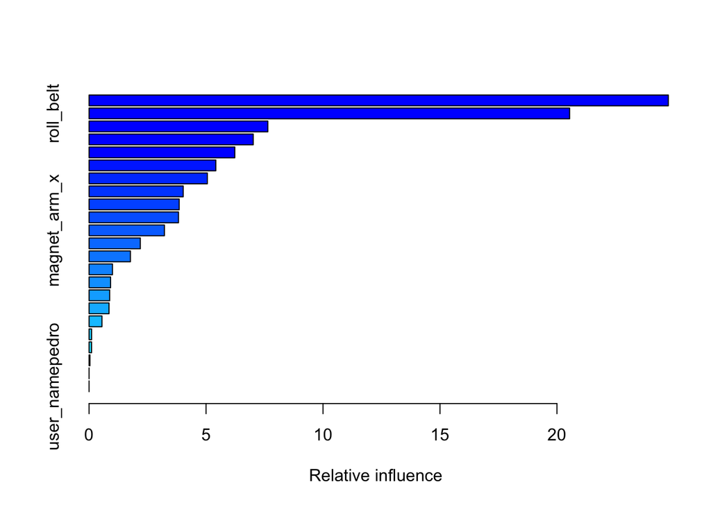

```
##                                 var     rel.inf
## num_window               num_window 24.76225470
## roll_belt                 roll_belt 20.54194714
## magnet_dumbbell_z magnet_dumbbell_z  7.64223310
## roll_forearm           roll_forearm  7.01655497
## magnet_dumbbell_y magnet_dumbbell_y  6.22963029
## yaw_belt                   yaw_belt  5.41723878
## accel_dumbbell_x   accel_dumbbell_x  5.05584506
## magnet_belt_z         magnet_belt_z  4.02480277
## accel_forearm_x     accel_forearm_x  3.85173628
## roll_dumbbell         roll_dumbbell  3.82268422
## magnet_arm_x           magnet_arm_x  3.22037781
## magnet_forearm_y   magnet_forearm_y  2.19074698
## magnet_forearm_x   magnet_forearm_x  1.76765209
## accel_arm_x             accel_arm_x  1.00061137
## magnet_belt_y         magnet_belt_y  0.91977374
## user_nameeurico     user_nameeurico  0.88103063
## magnet_dumbbell_x magnet_dumbbell_x  0.85231747
## magnet_arm_y           magnet_arm_y  0.55018029
## pitch_dumbbell       pitch_dumbbell  0.10802844
## user_namecharles   user_namecharles  0.10603857
## user_namejeremy     user_namejeremy  0.03831533
## user_namecarlitos user_namecarlitos  0.00000000
## user_namepedro       user_namepedro  0.00000000
```

```r
print(summary(fitMod))
```

Predicting on cross validation data set:

```r
pred=predict(fitMod,newdata=crossvls)
```

Let’s assess the model:

```r
cm=confusionMatrix(pred,crossvls$classe)
print(cm)
```

```
## Confusion Matrix and Statistics
##
##           Reference
## Prediction    A    B    C    D    E
##          A 1674    3    0    0    1
##          B    0 1129    3    5    3
##          C    0    5 1022   16    1
##          D    0    2    1  943    6
##          E    0    0    0    0 1071
##
## Overall Statistics
##
##                Accuracy : 0.9922
##                  95% CI : (0.9896, 0.9943)
##     No Information Rate : 0.2845
##     P-Value [Acc > NIR] : < 2.2e-16
##
##                   Kappa : 0.9901
##  Mcnemar's Test P-Value : NA
##
## Statistics by Class:
##
##                      Class: A Class: B Class: C Class: D Class: E
## Sensitivity            1.0000   0.9912   0.9961   0.9782   0.9898
## Specificity            0.9991   0.9977   0.9955   0.9982   1.0000
## Pos Pred Value         0.9976   0.9904   0.9789   0.9905   1.0000
## Neg Pred Value         1.0000   0.9979   0.9992   0.9957   0.9977
## Prevalence             0.2845   0.1935   0.1743   0.1638   0.1839
## Detection Rate         0.2845   0.1918   0.1737   0.1602   0.1820
## Detection Prevalence   0.2851   0.1937   0.1774   0.1618   0.1820
## Balanced Accuracy      0.9995   0.9945   0.9958   0.9882   0.9949
```

This result is OK for passing project test submission.

### Test submission

Predicting on the test data:

```r
predX=predict(fitMod,newdata=testing.data)
print(predX)
```

```
##  [1] B A B A A E D B A A B C B A E E A B B B
## Levels: A B C D E
```

100% result